# 1. Wgraj zbiór danych CO2 ')

```python
import pandas as pd
df = pd.read_csv('CO2 dataset.csv')
```

```python
df
```

|  | Year | Month | Decimal Date | Carbon Dioxide (ppm) | Seasonally Adjusted CO2 (ppm) | Carbon Dioxide Fit (ppm) | Seasonally Adjusted CO2 Fit (ppm) |
| --- | --- | --- | --- | --- | --- | --- | --- |
| 0 | 1958 | 1 | 1958.0411 | NaN | NaN | NaN | NaN |
| 1 | 1958 | 2 | 1958.1260 | NaN | NaN | NaN | NaN |
| 2 | 1958 | 3 | 1958.2027 | 315.69 | 314.42 | 316.18 | 314.89 |
| 3 | 1958 | 4 | 1958.2877 | 317.45 | 315.15 | 317.30 | 314.98 |
| 4 | 1958 | 5 | 1958.3699 | 317.50 | 314.73 | 317.83 | 315.06 |
| ... | ... | ... | ... | ... | ... | ... | ... |
| 715 | 2017 | 8 | 2017.6219 | NaN | NaN | NaN | NaN |
| 716 | 2017 | 9 | 2017.7068 | NaN | NaN | NaN | NaN |
| 717 | 2017 | 10 | 2017.7890 | NaN | NaN | NaN | NaN |
| 718 | 2017 | 11 | 2017.8740 | NaN | NaN | NaN | NaN |
| 719 | 2017 | 12 | 2017.9562 | NaN | NaN | NaN | NaN |

720 rows × 7 columns

## 2. Stwórz wykres pamiętając o podpisaniu osi

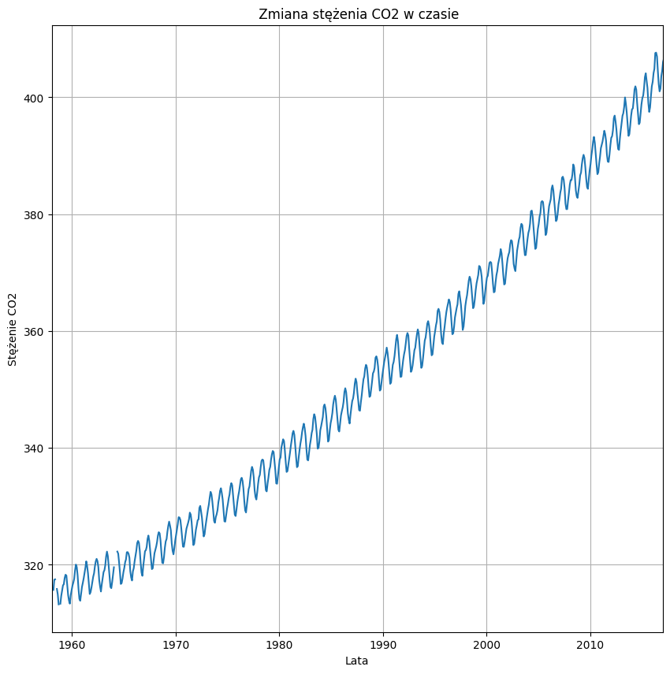

```python
import matplotlib.pyplot as plt
import seaborn as sns
fig, ax = plt.subplots(1, 1, figsize = [10, 10])

ax.plot(df['Decimal Date'], df['Carbon Dioxide (ppm)'])
ax.set_xlabel("Lata")
ax.set_ylabel("Stężenie CO2")
ax.set_title(" Zmiana stężenia CO2 w czasie")
ax.set_xlim(min(df['Decimal Date']), max(df['Year']))
ax.grid(True)
```

# 3. Określ sezonowość i wylicz krzywą trendu.

Przykładowo dla danych o częstotliwości miesięcznej oraz rocznej sezonowości zjawiska potrzebne będzie stworzenie okna w rozmiarze 12. Jeśli okresowość naszego zjawiska jest liczbą nieparzystą to średnią kroczącą do wyliczenia trendu możemy obliczyć dla okna 1xT, natomiast gdy jest liczbą parzystą używamy okna 2xT. Wykonujemy ten krok by pozbyć się fluktuacji sezonowych.

```python
rozmiar_okna = 12
df["Trend"] = df['Carbon Dioxide (ppm)'].rolling(window = rozmiar_okna).mean().rolling(window = 2).mean().shift(-rozmiar_okna // 2)
```

# 4. Wykonaj wizualizację sygnału wejściowego oraz trendu na jednym wykresie

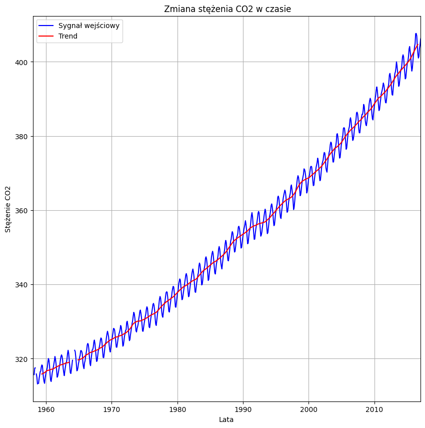

```python
fig, ax = plt.subplots(1, 1, figsize = [10, 10])
ax.plot(df['Decimal Date'], df['Carbon Dioxide (ppm)'], label = 'Sygnał wejściowy', color = 'blue')
ax.plot(df['Decimal Date'], df['Trend'], label='Trend', color='red')
ax.set_xlabel("Lata")
ax.set_ylabel("Stężenie CO2")
ax.set_title(" Zmiana stężenia CO2 w czasie")
ax.set_xlim(min(df['Year']), max(df['Year']))
ax.grid(True)
ax.legend()
```

# 5. Odejmij od sygnału wejściowego wyliczony trend i wykonaj na jednym wykresie wykres wszystkich trzech składowych w celu sprawdzenia. Skomentuj KRÓTKO wynik

```python
df["Input_detrended"] = df['Carbon Dioxide (ppm)'] - df["Trend"]
```

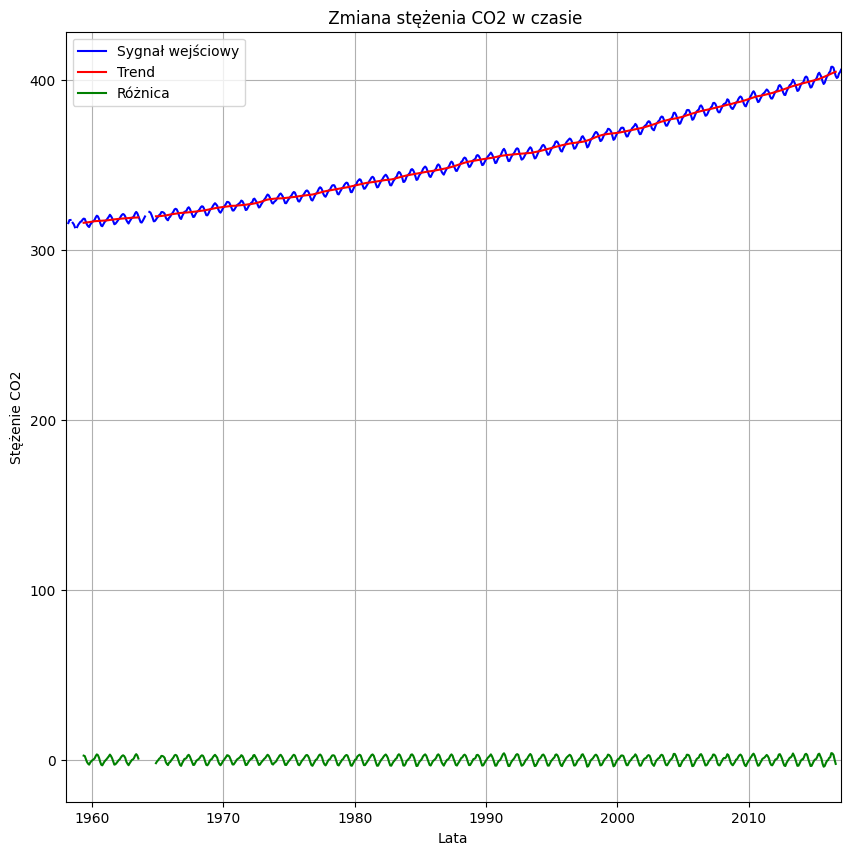

```python
fig, ax = plt.subplots(1, 1, figsize = [10, 10])
ax.plot(df['Decimal Date'], df['Carbon Dioxide (ppm)'], label = 'Sygnał wejściowy', color = 'blue')
ax.plot(df['Decimal Date'], df['Trend'], label='Trend', color = 'red')
ax.plot(df['Decimal Date'], df["Input_detrended"], label='Różnica', color = 'green')
ax.set_xlabel("Lata")
ax.set_ylabel("Stężenie CO2")
ax.set_title(" Zmiana stężenia CO2 w czasie")
ax.set_xlim(min(df['Year']), max(df['Year']))
ax.grid(True)
ax.legend()
```

Trend dobrze ukazuje wzrost CO2 w czasie. Oscylująca w pobliżu zera różnica pomiędzy sygnałem wejściowym, a trendem potwierdza odpowiednio zidentyfikowany trend.

# 6. Wylicz średnia szeregu czasowego po odfiltrowaniu trendu dla danej częstotliwości i skomentuj wynik. Oto przykład dla częstotliwości miesięcznej:

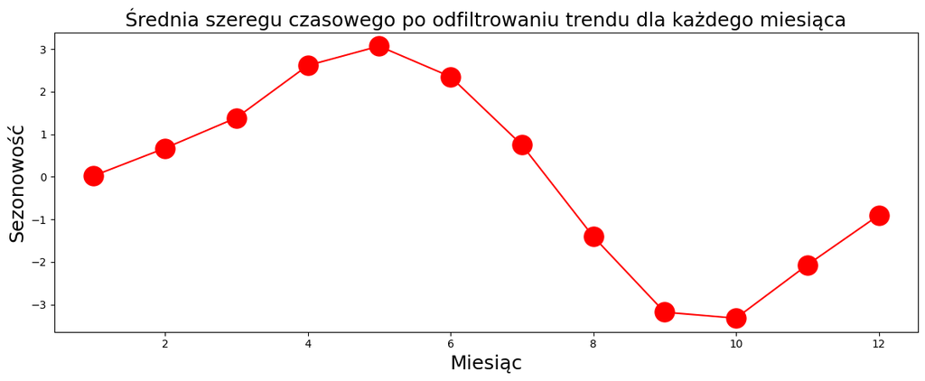

```python
# Średnia dla każdego miesiąca
#df["Miesiac"] = df.index.month
sezonowosc = df.groupby("Month").mean()["Input_detrended"]
sezonowosc.name = "sezonowosc"
fig, ax = plt.subplots(figsize=[12, 5])
sezonowosc.plot(y="sezonowosc", ax=ax, marker="o", color="red", markersize=18)
ax.set_xlabel("Miesiąc", fontsize=18)
ax.set_ylabel("Sezonowość", fontsize=18)
ax.set_title("Średnia szeregu czasowego po odfiltrowaniu trendu dla każdego miesiąca", fontsize=18)
plt.tight_layout()
```

Widoczna jest sezonowość miesięczna. Widoczny jest spadek stężenia CO2 w miesiącach ciepłych. Najprawdopodbniej istnieje zależność pomiędzy średnią tempetaturą w miesiącu a stężeniem CO2.

# 7. Powtórz pattern sezonowości wyliczony w kroku 6 i oblicz rezydua

```python
df = df.merge(right = sezonowosc, left_on="Month", right_index = True)
df = df.sort_index()
df.head()
df["residual"] = df['Carbon Dioxide (ppm)'] - df["Trend"] - df["sezonowosc"]
```

# 8. Wykonaj wykres dla rezyduów

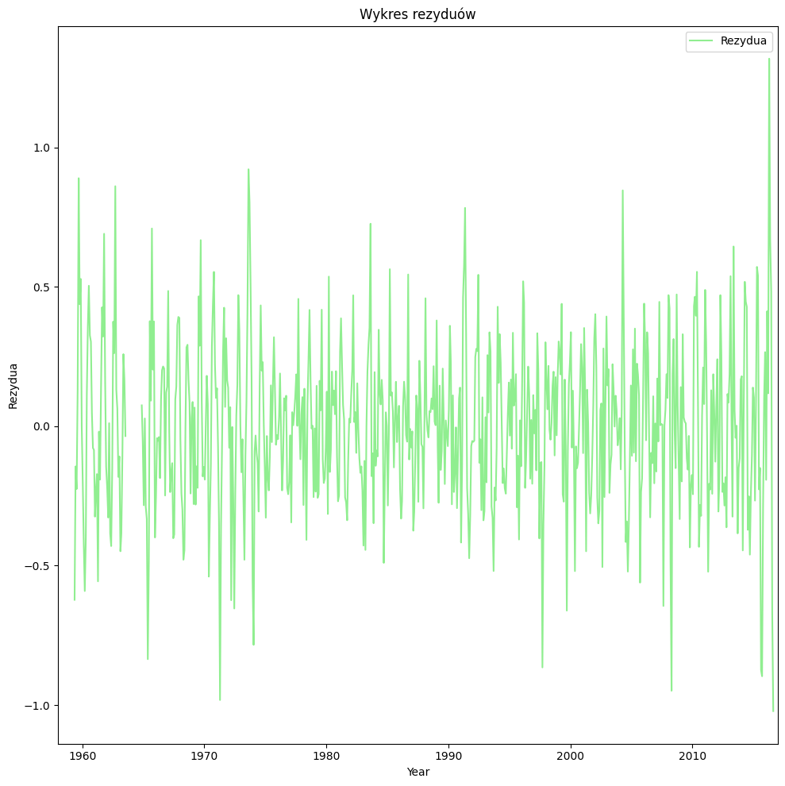

```python
fig, ax = plt.subplots(1, 1, figsize = [10, 10])

ax.plot(df['Decimal Date'], df['residual'], label='Rezydua', color='lightgreen')
ax.set_xlabel('Year')
ax.set_ylabel('Rezydua')
ax.set_title('Wykres rezyduów')
ax.set_xlim(min(df['Year']), max(df['Year']))
ax.legend()
plt.tight_layout()
```

# 9. Wykonaj zbiorczy wykres i krótki zinterpretuj wyniki.

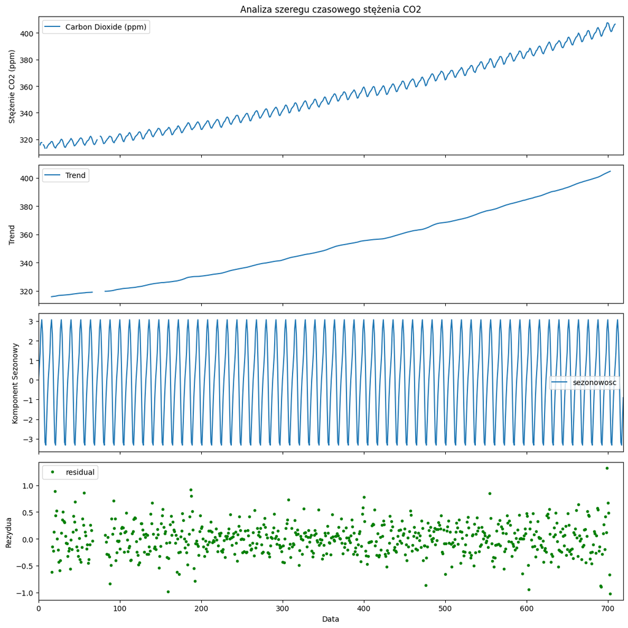

```python
fig, ax = plt.subplots(4, 1, figsize=[12, 12], sharex=True)

df["Carbon Dioxide (ppm)"].plot(ax = ax[0], legend="Input")
ax[0].set_ylabel("Stężenie CO2 (ppm)")
ax[0].set_xlim(min(df.index), max(df.index))

df["Trend"].plot(ax=ax[1], legend="Trend")
ax[1].set_ylabel("Trend")
ax[1].set_xlim(min(df.index), max(df.index))

df["sezonowosc"].plot(ax=ax[2], legend="Sezonowość")
ax[2].set_ylabel("Komponent Sezonowy")
ax[2].set_xlim(min(df.index), max(df.index))

df["residual"].plot(ax=ax[3], marker=".", legend = "Residua", ls="None", color="green")
ax[3].set_ylabel("Rezydua")
ax[3].set_xlim(min(df.index), max(df.index))

ax[0].set_title("Analiza szeregu czasowego stężenia CO2")
ax[3].set_xlabel("Data")

plt.tight_layout()
```

1. Z roku na rok rośnie stężenie CO2 - wykres trendu.
2. Stężenie CO2 posiada sezonowość miesięczną w skali roku - wykres sezonowości.
3. Resiuda prezentują się podobnie dla całego zbioru danych - wykres residuów.